# Reproducible Research: Peer Assessment 1

## Loading and preprocessing the data

- Reading the data

```r
Activity = read.csv("activity.csv", header = TRUE)
```

- Checking out first and last few entries

```r
head(Activity)
```

```
##   steps       date interval
## 1    NA 2012-10-01        0
## 2    NA 2012-10-01        5
## 3    NA 2012-10-01       10
## 4    NA 2012-10-01       15
## 5    NA 2012-10-01       20
## 6    NA 2012-10-01       25
```

```r
tail(Activity)
```

```
##       steps       date interval
## 17563    NA 2012-11-30     2330
## 17564    NA 2012-11-30     2335
## 17565    NA 2012-11-30     2340
## 17566    NA 2012-11-30     2345
## 17567    NA 2012-11-30     2350
## 17568    NA 2012-11-30     2355
```

## What is mean total number of steps taken per day?

- 1. Calculate the total number of steps taken per day

```r
Steps <- aggregate(steps ~ date, Activity, sum, na.rm = TRUE)
#Steps
```

- 2. Make a histogram of the total number of steps taken each day

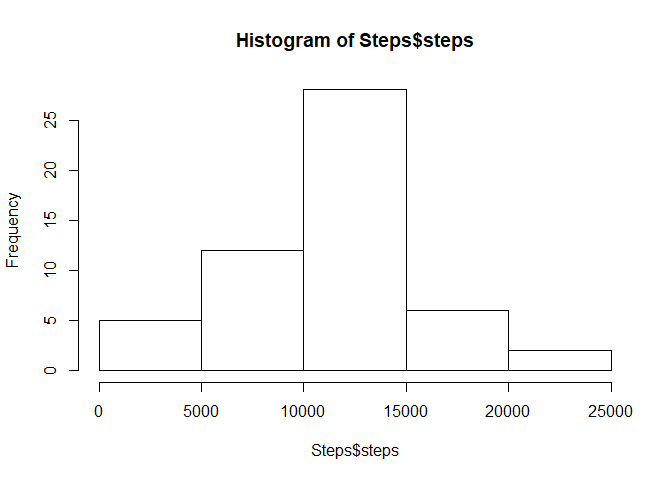

```r
hist(Steps$steps)
```

- 3. Calculate and report the mean and median of the total number of steps taken per day

```r
mean(Steps$steps)
```

```
## [1] 10766.19
```

```r
median(Steps$steps)
```

```
## [1] 10765
```

## What is the average daily activity pattern?

```r
Step_Avg_TI <- aggregate(steps ~ interval, Activity, mean, na.rm = TRUE)
#Step_Avg_TI
```

- 1. Make a time series plot (i.e. type = “l”) of the 5-minute interval (x-axis) and the average number of steps taken, averaged across all days (y-axis)

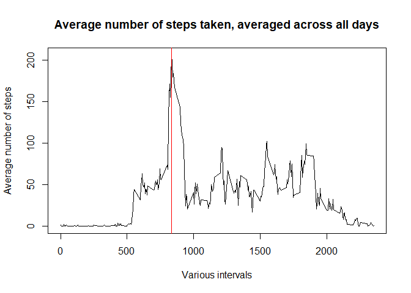

```r
n <- nrow(Step_Avg_TI)
Max_interval <- Step_Avg_TI[which.max(Step_Avg_TI$steps),]$interval
plot(Step_Avg_TI$interval, Step_Avg_TI$steps, type = "l", xlab = "Various intervals", ylab = "Average number of steps", main = "Average number of steps taken, averaged across all days")
abline( v = Max_interval, col = "red")
```

- 2. Which 5-minute interval, on average across all the days in the dataset, contains the maximum number of steps?

```r
Max_interval
```

```
## [1] 835
```